# IODS course project

## 4. i) Explain the relationship between the chosen explanatory variables and the target variable (interpret the model parameters) ii) Explain and interpret the multiple R squared of the model

### ii) Explain and interpret the multiple R squared of the model

Adjusted R-squared is 0.1927, so almost 20% of variation in exam points can be explained by attitude, strategic learning and surface learning. Adjusted R-squared is the more important measure as we have multiple explanatory variables.

## 5. Plots: Residuals vs Fitted values, Normal QQ-plot and Residuals vs Leverage.

Let’s produce the plots: Residual vs Fitted values, Normal QQ-plot and Residuals vs Leverage

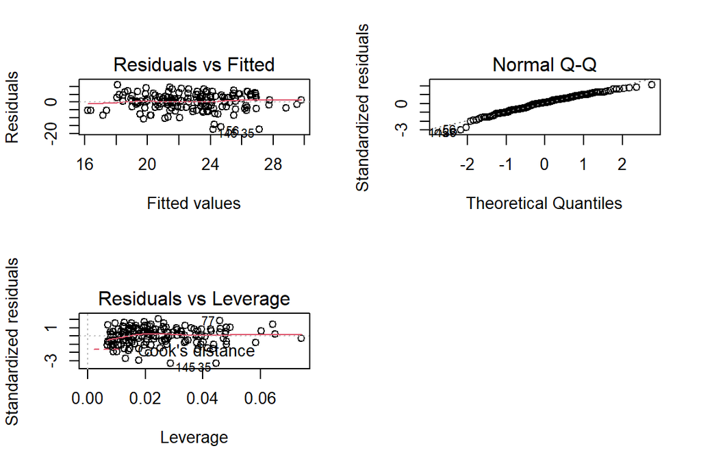

```r
# create the model again just in case
my_model <- lm(points ~ attitude + stra + surf, data = learning2014)

# draw diagnostic plots using the plot() function. Choose the plots Residual vs Fitted values, Normal QQ-plot and Residuals vs Leverage (which are 1,2 and 5)
par(mfrow = c(2,2))
plot(my_model, which = c(1,2,5))
```

**Residuals vs Fitted:** Reasonable random spread of points. So there shouldn’t be a problem with the assumptions.

**Normal Q-Q:** In the middle there seems to quite good fit to the normality line, but in the beginning and in the end there is a deviation from the line. So there isn’t a reasonable with to the normality assumption.

**Residuals vs Leverage:** this plot can help to identify observations that have unusually high impact. There is seemingly few outlier values in the bottom of the plot. So these outliers may highly impact the model in question.

# RStudio Exercise 3

## 2. Read data

```r
alc <- read.csv("https://github.com/rsund/IODS-project/raw/master/data/alc.csv", header = TRUE, sep = ",")

colnames(alc)
```

```
##  [1] "school"     "sex"        "age"        "address"    "famsize"
##  [6] "Pstatus"    "Medu"       "Fedu"       "Mjob"       "Fjob"
## [11] "reason"     "guardian"   "traveltime" "studytime"  "schoolsup"
## [16] "famsup"     "activities" "nursery"    "higher"     "internet"
## [21] "romantic"   "famrel"     "freetime"   "goout"      "Dalc"
## [26] "Walc"       "health"     "n"          "id.p"       "id.m"
## [31] "failures"   "paid"       "absences"   "G1"         "G2"
## [36] "G3"         "failures.p" "paid.p"     "absences.p" "G1.p"
## [41] "G2.p"       "G3.p"       "failures.m" "paid.m"     "absences.m"
## [46] "G1.m"       "G2.m"       "G3.m"       "alc_use"    "high_use"
## [51] "cid"
```

Original data set description can be found [here](https://archive.ics.uci.edu/ml/datasets/Student+Performance). The read data is combination of two data sets regarding the performance in Mathematics and Portuguese language. So originally two different data sets with same variables relating to student grades, demographic, social and school related features.

Variables/column names with suffix **.p** are originals from por (Portuguese language) dataset and **.m** from mat (Mathematics) dataset. The combination dataset in question has the following variables: “failures”, “paid”(first value selected), “absences”, “G1”, “G2”, “G3”, are averaged from mat and por datasets. “alc_use” is averaged from “Dalc” workday alcohol consumption (numeric: from 1 - very low to 5 - very high) and “Walc” - weekend alcohol consumption (numeric: from 1 - very low to 5 - very high). “high_use” is TRUE if ‘alc_use’ is higher than 2 and FALSE otherwise.

## 3. Choosing 4 interesing variables to study relationships between high/low alcohol consumption

**higher** - wants to take higher education. I hypothesize that students not wanting to take higher education would have higher alcohol consumption.

**famrel** - quality of family relationships (numeric: from 1 - very bad to 5 - excellent). I think family relationship might be an interesting variable that might be highly correlated with alcohol consumption as in students with bad family relationships would likely drink more and vice versa.

**age** - my hypothesis is that older persons will likely have higher alcohol consumption, as the age range is from 15 to 22, over 18 persons can buy alcohol legally.

**failures** - number of past class failures (numeric: n if 1<=n<3, else 4). I hypotize that high failures would correlate with high alcohol consumption.

## 4. Exploring distributions of previously chosen variables

Check our variable types etc.

```r
library(dplyr)
my_vars <- c("high_use", "higher", "age", "famrel", "failures")
interest_alc <- subset(alc, select = my_vars)

glimpse(interest_alc)
```

```
## Rows: 370
## Columns: 5
## $ high_use <lgl> FALSE, TRUE, FALSE, FALSE, TRUE, FALSE, FALSE, FALSE, TRUE, F~
## $ higher   <chr> "yes", "yes", "yes", "yes", "yes", "yes", "yes", "yes", "yes"~
## $ age      <int> 15, 15, 15, 15, 15, 15, 15, 15, 15, 15, 15, 15, 15, 15, 15, 1~
## $ famrel   <int> 3, 3, 4, 4, 4, 4, 4, 4, 4, 4, 4, 4, 4, 4, 4, 3, 5, 5, 3, 3, 4~
## $ failures <int> 0, 1, 0, 0, 1, 0, 1, 0, 0, 0, 0, 0, 0, 0, 0, 0, 0, 0, 0, 2, 0~
```

Let’s examine our selected variables’ “higher”’, “age”, “famrel”, “failures” and “high_use” count distuributions.

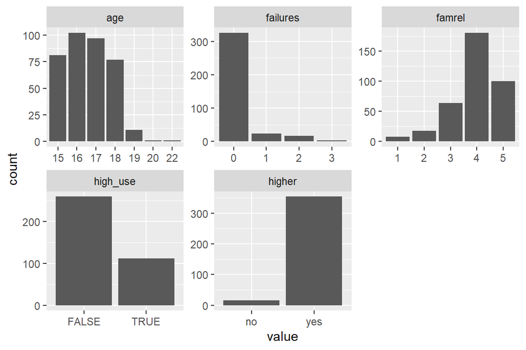

```r
library(tidyr); library(ggplot2)

gather(interest_alc) %>% ggplot(aes(value)) + facet_wrap("key", scales = "free") + geom_bar()
```

### higher

Interesting, it looks like most do want to take higher education. Let’s check the actual counts on that one and plot with them.

```r
alc %>% group_by(higher) %>% summarise(count = n())
```

```
## # A tibble: 2 x 2
##   higher count
##   <chr>  <int>
## 1 no        16
## 2 yes      354
```

```r
alc %>% group_by(high_use, higher) %>% summarise(count = n())
```

```
## # A tibble: 4 x 3
## # Groups:   high_use [2]
##   high_use higher count
##   <lgl>    <chr>  <int>
## 1 FALSE    no         7
## 2 FALSE    yes      252
## 3 TRUE     no         9
## 4 TRUE     yes      102
```

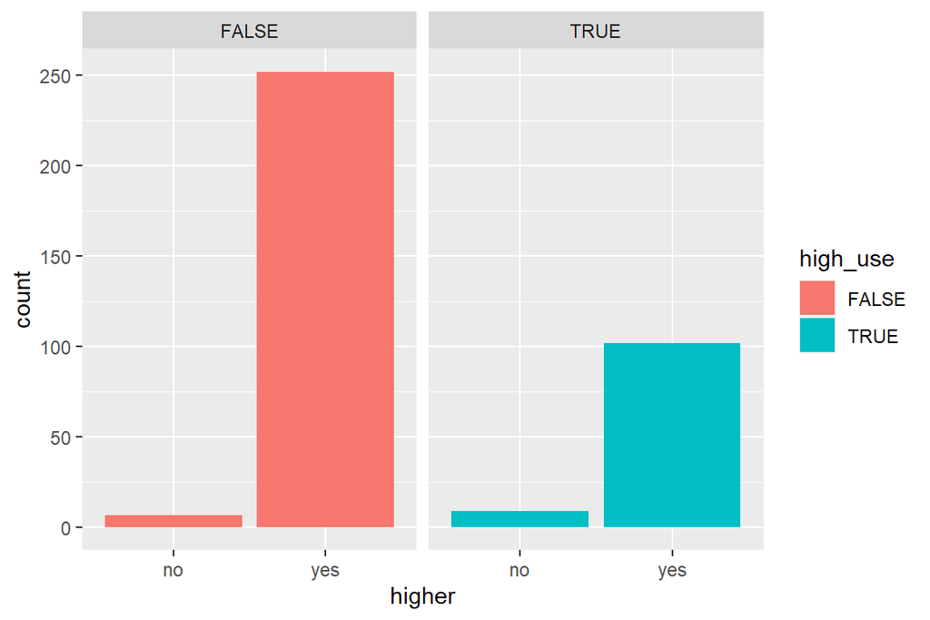

```r
alc %>% group_by(high_use, higher) %>% summarise(count = n()) %>%
   ggplot(aes(x = higher, y = count, fill = high_use)) +
   geom_col() +
   facet_wrap("high_use")
```

### famrel

Summarize counts of high_use by famrel in table and in barplot.

```r
alc %>% group_by(high_use, famrel) %>% summarise(count = n())
```

```
## # A tibble: 10 x 3
## # Groups:   high_use [2]
##    high_use famrel count
##    <lgl>     <int> <int>
##  1 FALSE         1     6
##  2 FALSE         2     9
##  3 FALSE         3    39
##  4 FALSE         4   128
##  5 FALSE         5    77
##  6 TRUE          1     2
##  7 TRUE          2     9
##  8 TRUE          3    25
##  9 TRUE          4    52
## 10 TRUE          5    23
```

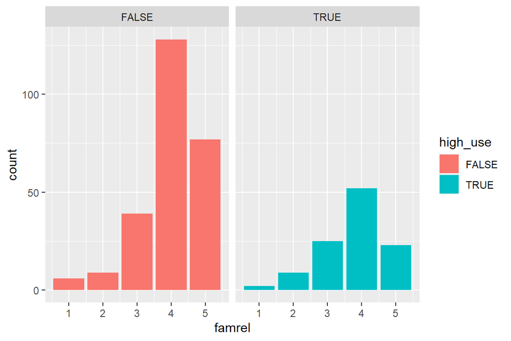

```r
alc %>% group_by(high_use, famrel) %>% summarise(count = n()) %>%
   ggplot(aes(x = famrel, y = count, fill = high_use)) +
   geom_col() +
   facet_wrap("high_use")
```

*famrel - quality of family relationships (numeric: from 1 - very bad to 5 - excellent)*. Bad family relations was lower number and good were higher number. Looks like my hypothesis is rather poor in this one. The counts for high_use and bad family relationships are very low. Overall bad family relationships are seem to pretty low with students.

### failures

Summarize counts of high_use by failures in table and in barplot.

```r
alc %>% group_by(high_use, failures) %>% summarise(count = n())
```

```
## # A tibble: 8 x 3
## # Groups:   high_use [2]
##   high_use failures count
##   <lgl>       <int> <int>
## 1 FALSE           0   238
## 2 FALSE           1    12
## 3 FALSE           2     8
## 4 FALSE           3     1
## 5 TRUE            0    87
## 6 TRUE            1    12
## 7 TRUE            2     9
## 8 TRUE            3     3
```

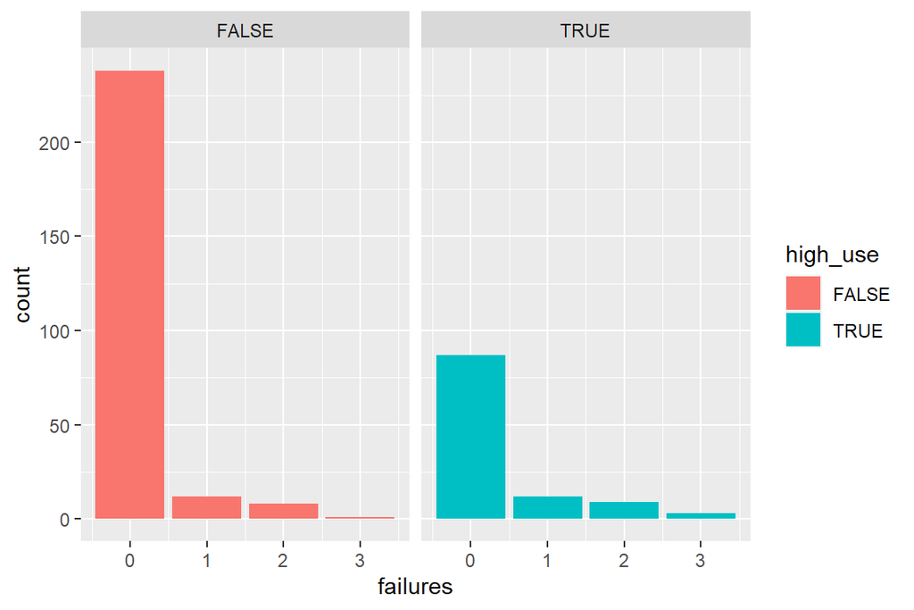

```r
alc %>% group_by(high_use, failures) %>% summarise(count = n()) %>%
   ggplot(aes(x = failures, y = count, fill = high_use)) +
   geom_col() +
   facet_wrap("high_use")
```

### age

```r
alc %>% group_by(high_use) %>% summarise(mean = mean(age))
```

```
## # A tibble: 2 x 2
##   high_use  mean
##   <lgl>    <dbl>
## 1 FALSE     16.5
## 2 TRUE      16.8
```

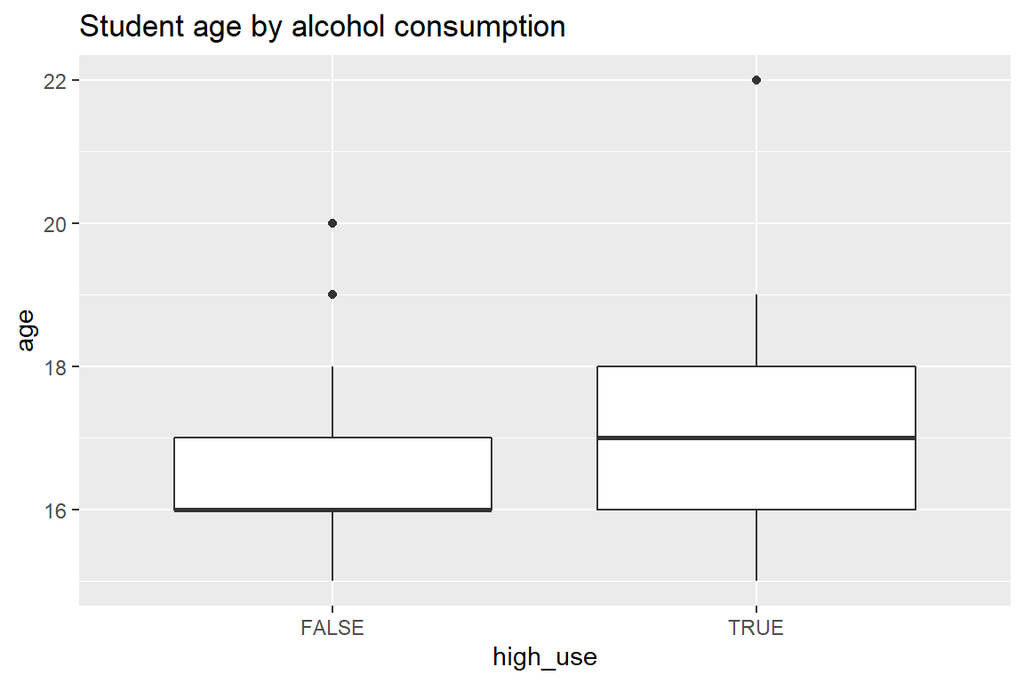

```r
# initialise a plot of high_use and age
g2 <- ggplot(alc, aes(x = high_use, y = age))

# define the plot as a boxplot and draw it
g2 + geom_boxplot() + ggtitle("Student age by alcohol consumption")
```

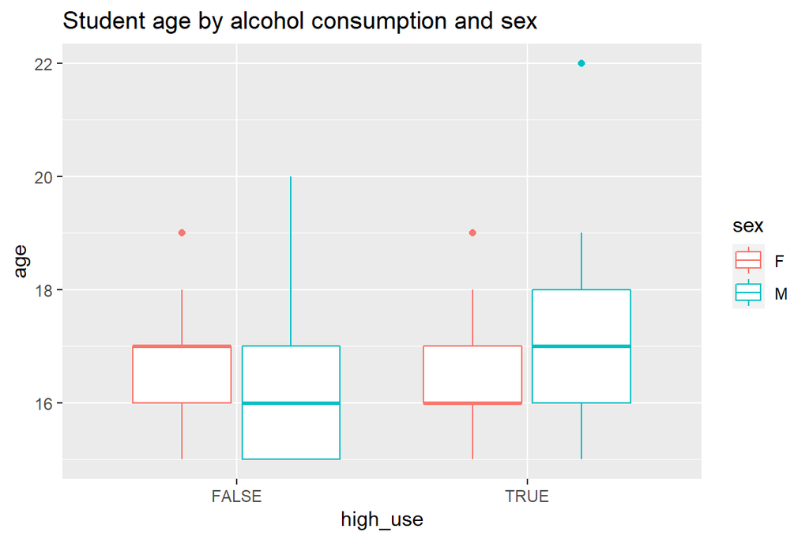

```r
# lets also seem the same with sex added
g3 <- ggplot(alc, aes(x = high_use, y = age, col = sex))
g3 + geom_boxplot() + ggtitle("Student age by alcohol consumption and sex")
```

```r
alc %>% group_by(high_use, age) %>% summarise(count = n())
```

```
## # A tibble: 12 x 3
## # Groups:   high_use [2]
##    high_use   age count
##    <lgl>    <int> <int>
##  1 FALSE       15    63
##  2 FALSE       16    74
##  3 FALSE       17    62
##  4 FALSE       18    52
##  5 FALSE       19     7
##  6 FALSE       20     1
##  7 TRUE        15    18
##  8 TRUE        16    28
##  9 TRUE        17    35
## 10 TRUE        18    25
## 11 TRUE        19     4
## 12 TRUE        22     1
```

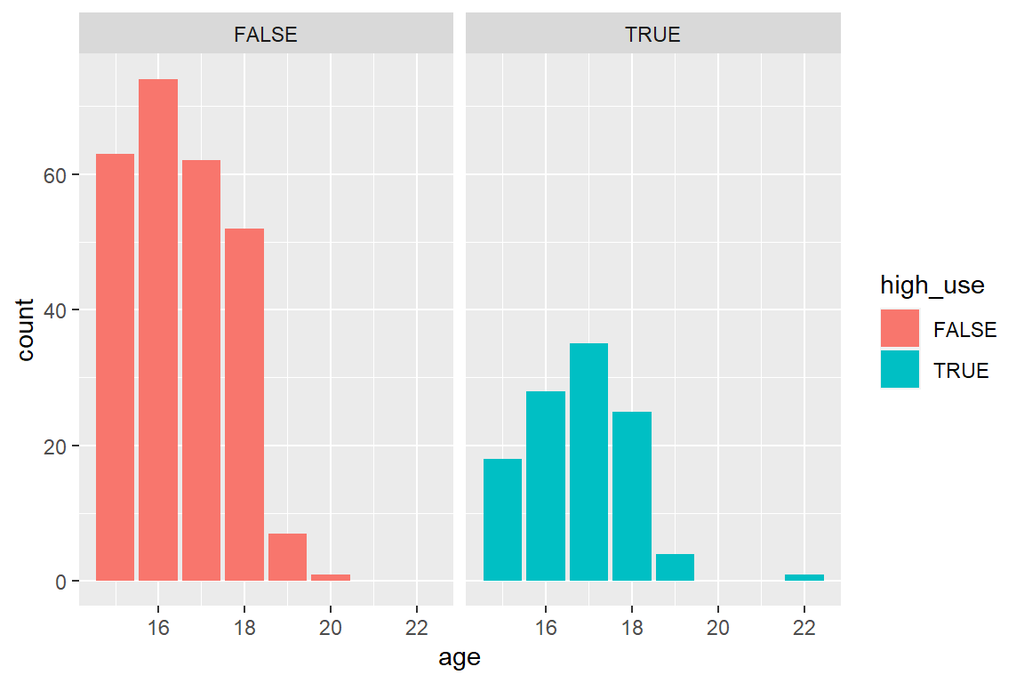

```r
alc %>% group_by(high_use, age) %>% summarise(count = n()) %>%
   ggplot(aes(x = age, y = count, fill = high_use)) +
   geom_col() +
   facet_wrap("high_use")
```

Average age for higher use is slightly higher, but there does not seem to be a that much more higher age for high alcohol consuming students especially over or 18.

## 5. Logistic regression with chosen variables

We’ll perform logistic regression to explore the relationships between the famrel, age, higher, failures variables with high/low alcohol consumption as target variable

```r
log_reg_model <- glm(high_use ~ famrel + age + higher + failures, data = alc, family = "binomial")
summary(log_reg_model)
```

```
##
## Call:
## glm(formula = high_use ~ famrel + age + higher + failures, family = "binomial",
##     data = alc)
##
## Deviance Residuals:
##     Min       1Q   Median       3Q      Max
## -1.6954  -0.8036  -0.7110   1.3402   1.8570
##
## Coefficients:
##             Estimate Std. Error z value Pr(>|z|)
## (Intercept)  -1.7777     1.9341  -0.919   0.3580
## famrel       -0.2815     0.1254  -2.245   0.0248 *
## age           0.1405     0.1029   1.365   0.1723
## higheryes    -0.4499     0.5899  -0.763   0.4457
## failures      0.5594     0.2102   2.661   0.0078 **
## ---
## Signif. codes:  0 '***' 0.001 '**' 0.01 '*' 0.05 '.' 0.1 ' ' 1
##
## (Dispersion parameter for binomial family taken to be 1)
##
##     Null deviance: 452.04  on 369  degrees of freedom
## Residual deviance: 432.08  on 365  degrees of freedom
## AIC: 442.08
##
## Number of Fisher Scoring iterations: 4
```

```r
# compute odds ratios (OR)
OR <- coef(log_reg_model) %>% exp

# compute confidence intervals (CI)
CI <- confint(log_reg_model) %>% exp
# print out the odds ratios with their confidence intervals
cbind(OR, CI)
```

```
##                    OR       2.5 %    97.5 %
## (Intercept) 0.1690283 0.003738272 7.4864947
## famrel      0.7546270 0.589068018 0.9650944
## age         1.1508478 0.941172724 1.4104114
## higheryes   0.6376962 0.198545179 2.0808162
## failures    1.7495838 1.162299822 2.6710151
```

Seems a bit off since we can’t see other factors for famrel. Let’s add factors.

```r
log_reg_model <- glm(high_use ~ factor(famrel) + age + factor(higher) + failures, data = alc, family = "binomial")
summary(log_reg_model)
```

```
##
## Call:
## glm(formula = high_use ~ factor(famrel) + age + factor(higher) +
##     failures, family = "binomial", data = alc)
##
## Deviance Residuals:
##     Min       1Q   Median       3Q      Max
## -1.7501  -0.8559  -0.7101   1.2656   1.8934
##
## Coefficients:
##                   Estimate Std. Error z value Pr(>|z|)
## (Intercept)        -3.1286     2.0803  -1.504  0.13260
## factor(famrel)2     0.8850     0.9551   0.927  0.35411
## factor(famrel)3     0.5687     0.8622   0.660  0.50949
## factor(famrel)4     0.1298     0.8381   0.155  0.87693
## factor(famrel)5    -0.2315     0.8574  -0.270  0.78714
## age                 0.1445     0.1036   1.395  0.16310
## factor(higher)yes  -0.4172     0.5945  -0.702  0.48281
## failures            0.5515     0.2122   2.599  0.00934 **
## ---
## Signif. codes:  0 '***' 0.001 '**' 0.01 '*' 0.05 '.' 0.1 ' ' 1
##
## (Dispersion parameter for binomial family taken to be 1)
##
##     Null deviance: 452.04  on 369  degrees of freedom
## Residual deviance: 429.86  on 362  degrees of freedom
## AIC: 445.86
##
## Number of Fisher Scoring iterations: 4
```

```r
# compute odds ratios (OR)
OR <- coef(log_reg_model) %>% exp

# compute confidence intervals (CI)
CI <- confint(log_reg_model) %>% exp
# print out the odds ratios with their confidence intervals
cbind(OR, CI)
```

```
##                           OR        2.5 %    97.5 %
## (Intercept)       0.04377755 0.0006880176  2.482282
## factor(famrel)2   2.42308808 0.4105189123 20.100563
## factor(famrel)3   1.76605639 0.3673243645 12.821709
## factor(famrel)4   1.13859072 0.2499432346  7.999589
## factor(famrel)5   0.79333156 0.1665015354  5.717950
## age               1.15541978 0.9437919758  1.417882
## factor(higher)yes 0.65888088 0.2035056764  2.170862
## failures          1.73582033 1.1481286518  2.658353
```

Let’s try model without intercept.

```r
log_reg_model <- glm(high_use ~ factor(famrel) + age + factor(higher) + failures -1, data = alc, family = "binomial")
summary(log_reg_model)
```

```
##
## Call:
## glm(formula = high_use ~ factor(famrel) + age + factor(higher) +
##     failures - 1, family = "binomial", data = alc)
##
## Deviance Residuals:
##     Min       1Q   Median       3Q      Max
## -1.7501  -0.8559  -0.7101   1.2656   1.8934
##
## Coefficients:
##                   Estimate Std. Error z value Pr(>|z|)
## factor(famrel)1    -3.1286     2.0803  -1.504  0.13260
## factor(famrel)2    -2.2436     1.9831  -1.131  0.25792
## factor(famrel)3    -2.5599     1.9126  -1.338  0.18075
## factor(famrel)4    -2.9988     1.9279  -1.556  0.11982
## factor(famrel)5    -3.3601     1.9482  -1.725  0.08458 .
## age                 0.1445     0.1036   1.395  0.16310
## factor(higher)yes  -0.4172     0.5945  -0.702  0.48281
## failures            0.5515     0.2122   2.599  0.00934 **
## ---
## Signif. codes:  0 '***' 0.001 '**' 0.01 '*' 0.05 '.' 0.1 ' ' 1
##
## (Dispersion parameter for binomial family taken to be 1)
##
##     Null deviance: 512.93  on 370  degrees of freedom
## Residual deviance: 429.86  on 362  degrees of freedom
## AIC: 445.86
##
## Number of Fisher Scoring iterations: 4
```

```r
# compute odds ratios (OR)
OR <- coef(log_reg_model) %>% exp

# compute confidence intervals (CI)
CI <- confint(log_reg_model) %>% exp
# print out the odds ratios with their confidence intervals
cbind(OR, CI)
```

```
##                           OR        2.5 %   97.5 %
## factor(famrel)1   0.04377755 0.0006880176 2.482282
## factor(famrel)2   0.10607686 0.0021202344 5.145847
## factor(famrel)3   0.07731362 0.0017718458 3.260660
## factor(famrel)4   0.04984471 0.0011021640 2.152387
## factor(famrel)5   0.03473011 0.0007347747 1.554473
## age               1.15541978 0.9437919758 1.417882
## factor(higher)yes 0.65888088 0.2035056764 2.170862
## failures          1.73582033 1.1481286518 2.658353
```

# RStudio Exercise 4

## 2. Loading data (Boston)

```r
# access the MASS package
library(MASS)
# load the data
data("Boston")

# Structure and dimensions of the data
str(Boston)
```

```
## 'data.frame':    506 obs. of  14 variables:
##  $ crim   : num  0.00632 0.02731 0.02729 0.03237 0.06905 ...
##  $ zn     : num  18 0 0 0 0 0 12.5 12.5 12.5 12.5 ...
##  $ indus  : num  2.31 7.07 7.07 2.18 2.18 2.18 7.87 7.87 7.87 7.87 ...
##  $ chas   : int  0 0 0 0 0 0 0 0 0 0 ...
##  $ nox    : num  0.538 0.469 0.469 0.458 0.458 0.458 0.524 0.524 0.524 0.524 ...
##  $ rm     : num  6.58 6.42 7.18 7 7.15 ...
##  $ age    : num  65.2 78.9 61.1 45.8 54.2 58.7 66.6 96.1 100 85.9 ...
##  $ dis    : num  4.09 4.97 4.97 6.06 6.06 ...
##  $ rad    : int  1 2 2 3 3 3 5 5 5 5 ...
##  $ tax    : num  296 242 242 222 222 222 311 311 311 311 ...
##  $ ptratio: num  15.3 17.8 17.8 18.7 18.7 18.7 15.2 15.2 15.2 15.2 ...
##  $ black  : num  397 397 393 395 397 ...
##  $ lstat  : num  4.98 9.14 4.03 2.94 5.33 ...
##  $ medv   : num  24 21.6 34.7 33.4 36.2 28.7 22.9 27.1 16.5 18.9 ...
```

Original data description can be found [here](https://stat.ethz.ch/R-manual/R-devel/library/MASS/html/Boston.html).

The Boston data frame is of housing values in suburbs of Boston and it has 506 rows and 14 columns.

**crim** per capita crime rate by town.  
**zn** proportion of residential land zoned for lots over 25,000 sq.ft.  
**indus** proportion of non-retail business acres per town.  
**chas** Charles River dummy variable (= 1 if tract bounds river; 0 otherwise).  
**nox** nitrogen oxides concentration (parts per 10 million).  
**rm** average number of rooms per dwelling.  
**age** proportion of owner-occupied units built prior to 1940.  
**dis** weighted mean of distances to five Boston employment centres.  
**rad** index of accessibility to radial highways.  
**tax** full-value property-tax rate per $10,000.  
**ptratio** pupil-teacher ratio by town.  
**black** 1000(Bk - 0.63)^2 where Bk is the proportion of blacks by town.  
**lstat** lower status of the population (percent).  
**medv** median value of owner-occupied homes in $1000s.